# Project: Medical Appointment - No Show (Healthcare Industry)

- Introduction
- Data Wrangling
- Exploratory Data Analysis
- Conclusions

## Introduction

> The aim of this report will be analyzing and drawing conclusions around a healthcare dataset related to Dr Appointment and No show from patients. Firtly I will load libraries and the data set, second I will wrangle and analyse the data to help us answer the below questions:
- Q1: Does certain neighbourhood have higher No show appointment rate?
- Q2: Do people financial background has a diret effect on No show appointment?
- Q3: what effect the duration between scheduling an appointment and the actual appointment have on No show?
- Q4: Do certain known medical conditions have higher No show appointment rates than others?

```python
# We start importing necessary required packages

import numpy as np
import pandas as pd
import matplotlib.pyplot as plt
import seaborn as sns
%matplotlib inline
```

## Data Wrangling

> Dataset will be loaded, checked, trimmed and cleaned to be made ready for analysis.

### General Properties

```python
# Loading the downloaded data
df_ns = pd.read_csv('noshowappointments-kagglev2-may-2016.csv')

# Starting with an intial high level data exploration by displaying all columns related to the first 5 rows.
df_ns.head()
```

|  | PatientId | AppointmentID | Gender | ScheduledDay | AppointmentDay | Age | Neighbourhood | Scholarship | Hipertension | Diabetes | Alcoholism | Handcap | SMS_received | No-show |
| --- | --- | --- | --- | --- | --- | --- | --- | --- | --- | --- | --- | --- | --- | --- |
| 0 | 2.987250e+13 | 5642903 | F | 2016-04-29T18:38:08Z | 2016-04-29T00:00:00Z | 62 | JARDIM DA PENHA | 0 | 1 | 0 | 0 | 0 | 0 | No |
| 1 | 5.589978e+14 | 5642503 | M | 2016-04-29T16:08:27Z | 2016-04-29T00:00:00Z | 56 | JARDIM DA PENHA | 0 | 0 | 0 | 0 | 0 | 0 | No |
| 2 | 4.262962e+12 | 5642549 | F | 2016-04-29T16:19:04Z | 2016-04-29T00:00:00Z | 62 | MATA DA PRAIA | 0 | 0 | 0 | 0 | 0 | 0 | No |
| 3 | 8.679512e+11 | 5642828 | F | 2016-04-29T17:29:31Z | 2016-04-29T00:00:00Z | 8 | PONTAL DE CAMBURI | 0 | 0 | 0 | 0 | 0 | 0 | No |
| 4 | 8.841186e+12 | 5642494 | F | 2016-04-29T16:07:23Z | 2016-04-29T00:00:00Z | 56 | JARDIM DA PENHA | 0 | 1 | 1 | 0 | 0 | 0 | No |

It can be noticed in the above table that the data set many characteristics related to each appointment. I will be using the No-show column as my 1D dependent variables. 2D dependent variables will be selected further down the report.

```python
# Exploring size of the data , ie: number of rows and columns
df_ns.shape
```

```
(110527, 14)
```

```python
# Exploring descriptive statistics of the data
df_ns.describe()
```

|  | PatientId | AppointmentID | Age | Scholarship | Hipertension | Diabetes | Alcoholism | Handcap | SMS_received |
| --- | --- | --- | --- | --- | --- | --- | --- | --- | --- |
| count | 1.105270e+05 | 1.105270e+05 | 110527.000000 | 110527.000000 | 110527.000000 | 110527.000000 | 110527.000000 | 110527.000000 | 110527.000000 |
| mean | 1.474963e+14 | 5.675305e+06 | 37.088874 | 0.098266 | 0.197246 | 0.071865 | 0.030400 | 0.022248 | 0.321026 |
| std | 2.560949e+14 | 7.129575e+04 | 23.110205 | 0.297675 | 0.397921 | 0.258265 | 0.171686 | 0.161543 | 0.466873 |
| min | 3.921784e+04 | 5.030230e+06 | -1.000000 | 0.000000 | 0.000000 | 0.000000 | 0.000000 | 0.000000 | 0.000000 |
| 25% | 4.172614e+12 | 5.640286e+06 | 18.000000 | 0.000000 | 0.000000 | 0.000000 | 0.000000 | 0.000000 | 0.000000 |
| 50% | 3.173184e+13 | 5.680573e+06 | 37.000000 | 0.000000 | 0.000000 | 0.000000 | 0.000000 | 0.000000 | 0.000000 |
| 75% | 9.439172e+13 | 5.725524e+06 | 55.000000 | 0.000000 | 0.000000 | 0.000000 | 0.000000 | 0.000000 | 1.000000 |
| max | 9.999816e+14 | 5.790484e+06 | 115.000000 | 1.000000 | 1.000000 | 1.000000 | 1.000000 | 4.000000 | 1.000000 |

From the above table , the following can be noticed:

Age: A minimum value of -1 require the column to be reviewed and cleaned for any value less than "0" Handcap: A max of 4 is not correct as values need to be True or False, ie 0 and 1 This is the first high level observation.

```python
# Exploring type of data in each column
df_ns.dtypes
```

```
PatientId         float64
AppointmentID       int64
Gender             object
ScheduledDay       object
AppointmentDay     object
Age                 int64
Neighbourhood      object
Scholarship         int64
Hipertension        int64
Diabetes            int64
Alcoholism          int64
Handcap             int64
SMS_received        int64
No-show            object
dtype: object
```

```python
# data exploration that define data type with quick cross check if any column has missing entry
df_ns.info()
```

```
<class 'pandas.core.frame.DataFrame'>
RangeIndex: 110527 entries, 0 to 110526
Data columns (total 14 columns):
PatientId         110527 non-null float64
AppointmentID     110527 non-null int64
Gender            110527 non-null object
ScheduledDay      110527 non-null object
AppointmentDay    110527 non-null object
Age               110527 non-null int64
Neighbourhood     110527 non-null object
Scholarship       110527 non-null int64
Hipertension      110527 non-null int64
Diabetes          110527 non-null int64
Alcoholism        110527 non-null int64
Handcap           110527 non-null int64
SMS_received      110527 non-null int64
No-show           110527 non-null object
dtypes: float64(1), int64(8), object(5)
memory usage: 11.8+ MB
```

The above require ScheduleDay and AppointmentDay type to be converted to datatime. In addition No-show will be converted to int to match the rest of the data.

```python
# Review any null value and its associated column
df_ns.isnull().sum()
```

```
PatientId         0
AppointmentID     0
Gender            0
ScheduledDay      0
AppointmentDay    0
Age               0
Neighbourhood     0
Scholarship       0
Hipertension      0
Diabetes          0
Alcoholism        0
Handcap           0
SMS_received      0
No-show           0
dtype: int64
```

It seems no null value/missing values in the data set.

```python
# Review any duplicated value and its associated column
df_ns.duplicated().sum()
```

```
0
```

No duplication can be found at this stage.

```python
# Explore number of unique entries in each column
df_ns.nunique()
```

```
PatientId          62299
AppointmentID     110527
Gender                 2
ScheduledDay      103549
AppointmentDay        27
Age                  104
Neighbourhood         81
Scholarship            2
Hipertension           2
Diabetes               2
Alcoholism             2
Handcap                5
SMS_received           2
No-show                2
dtype: int64
```

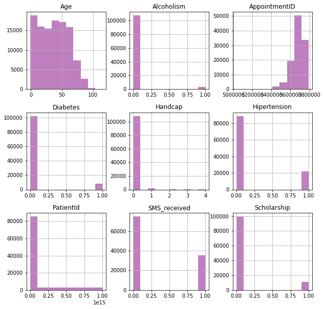

```python
# Exploring the data visual to get a better high level understanding
df_ns.hist(alpha=0.5, color='purple', figsize=(10,10));
```

Initial Analysis of the be above generated plots reveal that SMS_received is about 50% less to the not received. Moreover, Schorlarship (receiving social security benefit) data indicate that majority of the population in the dataset are not receiving this benefit. Further more, I will look at the duration between scheduled appointment day and actual appointment and if this have any direct effect on Show or No Show. In addition, I will also look at the neighbourhoods and if some neighbourhoods tend to miss their appointment more frequently than others.

### Data Cleaning

This section of the report , I will start Data Cleaning and address some of the initial problems highlighted above.

Firstly, schedule and appointment day columns will be transfer to date format. This is acheived by removing the time stamp from each data point followed by converging the string to datetime

```python
# Cleanning Schedule Day and Appointment Day by removning Time stamp.

# Let us select the 10 characters in the string related to the Date.
df_ns['ScheduledDay']=df_ns['ScheduledDay'].str[:10]
df_ns['AppointmentDay']=df_ns['AppointmentDay'].str[:10]
```

```python
# Confimring that the date coulmns have been modified
df_ns.head()
```

|  | PatientId | AppointmentID | Gender | ScheduledDay | AppointmentDay | Age | Neighbourhood | Scholarship | Hipertension | Diabetes | Alcoholism | Handcap | SMS_received | No-show |
| --- | --- | --- | --- | --- | --- | --- | --- | --- | --- | --- | --- | --- | --- | --- |
| 0 | 2.987250e+13 | 5642903 | F | 2016-04-29 | 2016-04-29 | 62 | JARDIM DA PENHA | 0 | 1 | 0 | 0 | 0 | 0 | No |
| 1 | 5.589978e+14 | 5642503 | M | 2016-04-29 | 2016-04-29 | 56 | JARDIM DA PENHA | 0 | 0 | 0 | 0 | 0 | 0 | No |
| 2 | 4.262962e+12 | 5642549 | F | 2016-04-29 | 2016-04-29 | 62 | MATA DA PRAIA | 0 | 0 | 0 | 0 | 0 | 0 | No |
| 3 | 8.679512e+11 | 5642828 | F | 2016-04-29 | 2016-04-29 | 8 | PONTAL DE CAMBURI | 0 | 0 | 0 | 0 | 0 | 0 | No |
| 4 | 8.841186e+12 | 5642494 | F | 2016-04-29 | 2016-04-29 | 56 | JARDIM DA PENHA | 0 | 1 | 1 | 0 | 0 | 0 | No |

```python
# Converting data to timestamp from String by creating the below function, func_date
# The function convert date Int to datetime

def func_date(date):
    return pd.to_datetime(date)

df_ns['ScheduledDay']=func_date(df_ns['ScheduledDay'])

df_ns['AppointmentDay']=func_date(df_ns['AppointmentDay'])
```

```python
# confimring that the date coulmns have been modified
df_ns.info()
```

```
<class 'pandas.core.frame.DataFrame'>
RangeIndex: 110527 entries, 0 to 110526
Data columns (total 14 columns):
PatientId         110527 non-null float64
AppointmentID     110527 non-null int64
Gender            110527 non-null object
ScheduledDay      110527 non-null datetime64[ns]
AppointmentDay    110527 non-null datetime64[ns]
Age               110527 non-null int64
Neighbourhood     110527 non-null object
Scholarship       110527 non-null int64
Hipertension      110527 non-null int64
Diabetes          110527 non-null int64
Alcoholism        110527 non-null int64
Handcap           110527 non-null int64
SMS_received      110527 non-null int64
No-show           110527 non-null object
dtypes: datetime64[ns](2), float64(1), int64(8), object(3)
memory usage: 11.8+ MB
```

Secondly, the Handcap column will be cleaned to ensure the only True /False entries are present.

```python
# Cleaning the Handcap column data that shows entries other than 0 "False' and 1 "True".
# Group by Handcap and count how many in each entry
df_ns.groupby('Handcap').count()
```

| Handcap | PatientId | AppointmentID | Gender | ScheduledDay | AppointmentDay | Age | Neighbourhood | Scholarship | Hipertension | Diabetes | Alcoholism | SMS_received | No-show |
| --- | --- | --- | --- | --- | --- | --- | --- | --- | --- | --- | --- | --- | --- |
| 0 | 108286 | 108286 | 108286 | 108286 | 108286 | 108286 | 108286 | 108286 | 108286 | 108286 | 108286 | 108286 | 108286 |
| 1 | 2042 | 2042 | 2042 | 2042 | 2042 | 2042 | 2042 | 2042 | 2042 | 2042 | 2042 | 2042 | 2042 |
| 2 | 183 | 183 | 183 | 183 | 183 | 183 | 183 | 183 | 183 | 183 | 183 | 183 | 183 |
| 3 | 13 | 13 | 13 | 13 | 13 | 13 | 13 | 13 | 13 | 13 | 13 | 13 | 13 |
| 4 | 3 | 3 | 3 | 3 | 3 | 3 | 3 | 3 | 3 | 3 | 3 | 3 | 3 |

The above clearly confirm the initial observation from the plots above, there are about 200 entries for Handcap that require cleaning.

```python
# Counting non True or False Entry for Handcap
df_ns.query('Handcap != (0,1)').count()
```

```
PatientId         199
AppointmentID     199
Gender            199
ScheduledDay      199
AppointmentDay    199
Age               199
Neighbourhood     199
Scholarship       199
Hipertension      199
Diabetes          199
Alcoholism        199
Handcap           199
SMS_received      199
No-show           199
dtype: int64
```

```python
# Drop Column with Hancap > 1, ie non conforming with True(1) or False(0)
df_ns.drop(df_ns[df_ns.Handcap > 1].index, inplace=True)
```

```python
# Confirming that no  Handcap data other than 0 & 1
df_ns.query('Handcap != (0,1)').count()
```

```
PatientId         0
AppointmentID     0
Gender            0
ScheduledDay      0
AppointmentDay    0
Age               0
Neighbourhood     0
Scholarship       0
Hipertension      0
Diabetes          0
Alcoholism        0
Handcap           0
SMS_received      0
No-show           0
dtype: int64
```

```python
# Checking the overall number of rows
df_ns.info()
```

```
<class 'pandas.core.frame.DataFrame'>
Int64Index: 110328 entries, 0 to 110526
Data columns (total 14 columns):
PatientId         110328 non-null float64
AppointmentID     110328 non-null int64
Gender            110328 non-null object
ScheduledDay      110328 non-null datetime64[ns]
AppointmentDay    110328 non-null datetime64[ns]
Age               110328 non-null int64
Neighbourhood     110328 non-null object
Scholarship       110328 non-null int64
Hipertension      110328 non-null int64
Diabetes          110328 non-null int64
Alcoholism        110328 non-null int64
Handcap           110328 non-null int64
SMS_received      110328 non-null int64
No-show           110328 non-null object
dtypes: datetime64[ns](2), float64(1), int64(8), object(3)
memory usage: 12.6+ MB
```

Thirdly, The Age column would be reviewed to ensure no outliers, This can be age less than 0. Age more than 100 has been kept as it cannot 100% confirmed if these are outliers or there is actual patient more than 100 years old.

```python
# Check and clean Age column for any age less than "0"
# count non True or False Entry
df_ns.query('Age < 0').count()
```

```
PatientId         1
AppointmentID     1
Gender            1
ScheduledDay      1
AppointmentDay    1
Age               1
Neighbourhood     1
Scholarship       1
Hipertension      1
Diabetes          1
Alcoholism        1
Handcap           1
SMS_received      1
No-show           1
dtype: int64
```

It is clear that there is 1 entry of age less than 0 than need to be dropped. This will be dropped below

```python
#Drop age column less than "0"
df_ns.drop(df_ns[df_ns.Age < 0].index, inplace=True)
```

```python
#Confirm no more age less than "0" through grupoing the data by age
df_ns.Age.describe()
```

```
count    110327.000000
mean         37.070753
std          23.098052
min           0.000000
25%          18.000000
50%          37.000000
75%          55.000000
max         115.000000
Name: Age, dtype: float64
```

Fourthly, No-show column will be amended by renaming the column to and replacing False True by 0 and 1

```python
# Replacing Show or no Show by 0 and 1 to be consitent with rest of the Columns
df_ns.rename(columns   = {'No-show':'noshow'}, inplace = True)
```

```python
# Replace noshow False or True by 0 and 1 to match rest of the data
df_ns['noshow']=df_ns['noshow'].replace('No',0)
df_ns['noshow']=df_ns['noshow'].replace('Yes',1);
```

```python
df_ns.groupby('noshow')['Age'].describe()
```

| noshow | count | mean | std | min | 25% | 50% | 75% | max |
| --- | --- | --- | --- | --- | --- | --- | --- | --- |
| 0 | 88049.0 | 37.777090 | 23.330356 | 0.0 | 18.0 | 38.0 | 56.0 | 115.0 |
| 1 | 22278.0 | 34.279109 | 21.935121 | 0.0 | 16.0 | 33.0 | 51.0 | 115.0 |

From the above it is observed that about 80% people show up to their appointment.

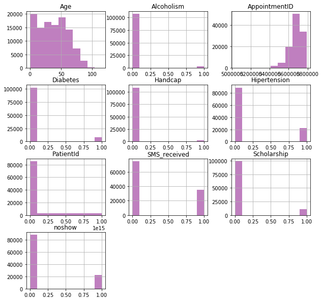

```python
# Ploting all data including noshow column
df_ns.hist(alpha=0.5, color='purple',figsize=(10,10));
```

Fifthly, Appointment ID column will be checked to confirm if any appointments have been duplicated and clean accordingly.

```python
# Will check if there is a any duplicate appointment ID
df_ns['AppointmentID'].duplicated().sum()
```

```
0
```

Lastly columns location in the dataset will be rearranged for better visual

```python
# Rearrange columns potions
df_ns=df_ns[['noshow','SMS_received','PatientId','Age','Gender','Scholarship','Neighbourhood','AppointmentID','ScheduledDay','AppointmentDay','Hipertension','Diabetes','Alcoholism','Handcap']]

df_ns.head()
```

|  | noshow | SMS_received | PatientId | Age | Gender | Scholarship | Neighbourhood | AppointmentID | ScheduledDay | AppointmentDay | Hipertension | Diabetes | Alcoholism | Handcap |
| --- | --- | --- | --- | --- | --- | --- | --- | --- | --- | --- | --- | --- | --- | --- |
| 0 | 0 | 0 | 2.987250e+13 | 62 | F | 0 | JARDIM DA PENHA | 5642903 | 2016-04-29 | 2016-04-29 | 1 | 0 | 0 | 0 |
| 1 | 0 | 0 | 5.589978e+14 | 56 | M | 0 | JARDIM DA PENHA | 5642503 | 2016-04-29 | 2016-04-29 | 0 | 0 | 0 | 0 |
| 2 | 0 | 0 | 4.262962e+12 | 62 | F | 0 | MATA DA PRAIA | 5642549 | 2016-04-29 | 2016-04-29 | 0 | 0 | 0 | 0 |
| 3 | 0 | 0 | 8.679512e+11 | 8 | F | 0 | PONTAL DE CAMBURI | 5642828 | 2016-04-29 | 2016-04-29 | 0 | 0 | 0 | 0 |
| 4 | 0 | 0 | 8.841186e+12 | 56 | F | 0 | JARDIM DA PENHA | 5642494 | 2016-04-29 | 2016-04-29 | 1 | 1 | 0 | 0 |

## Exploratory Data Analysis

Data Exploration will start by creating 2 columns associated with show and noshow to be called upon during the grouping.

```python
# Creating column associated with show and no show to be used in the analysis
no_show = df_ns.noshow == True
show = df_ns.noshow == False
```

Question 1: Does certain neighbourhood have higher No show appointment rate?

This question will be answered by grouping Neighbourhood column based noshow selection

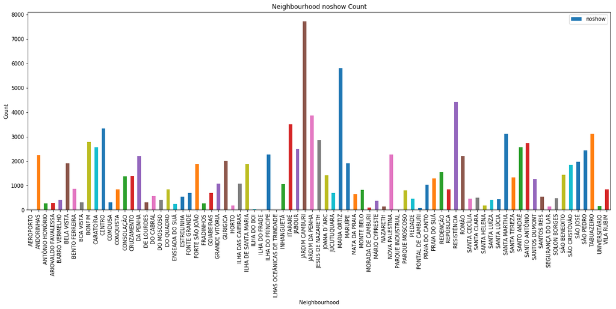

```python
# Plot is created for the grouping
fig, ax = plt.subplots(figsize=(20,7))
#plt.hist(
df_ns.groupby('Neighbourhood')['noshow'].describe()

n_noshow= df_ns.groupby('Neighbourhood').noshow.count().plot(kind='bar')
plt.legend()
plt.xlabel('Neighbourhood')
plt.ylabel('Count')
plt.title('Neighbourhood noshow Count');
```

Q2: Do people financial background has a diret effect on No show appointment?

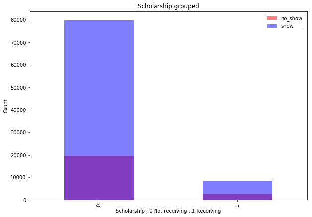

```python
# creating 2 seperate group by to distiction between effect of Scholarship on show/no_show
fig, ax = plt.subplots(figsize=(10,7))
df_ns.Scholarship[no_show].value_counts().plot(kind='bar',alpha=0.5,color='red' ,label='no_show')
df_ns.Scholarship[show].value_counts().plot(kind='bar', alpha=0.5, color='blue',label='show')
plt.legend()
plt.xlabel('Scholarship , 0 Not receiving , 1 Receiving')
plt.ylabel('Count')
plt.title('Scholarship grouped');
```

Question3: what effect the duration between scheduling an appointment and the actual appointment have on No show?

```python
#Duration between schedule day and appointment day is created and added to the dataset
duration = df_ns['AppointmentDay']-df_ns['ScheduledDay']
df_ns['duration']=duration
```

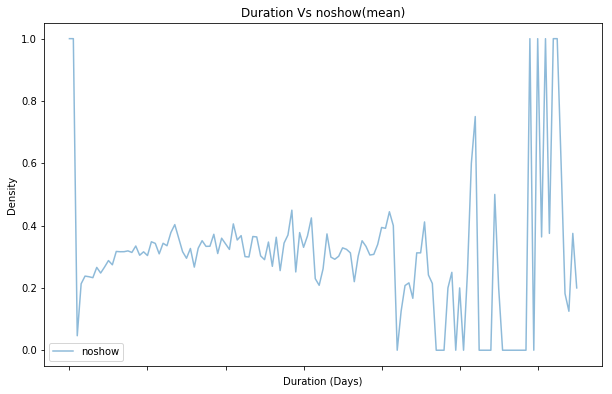

```python
#plot correlation between duration and mean of noshow
fig, ax = plt.subplots(figsize=(10,7))
df_ns.groupby('duration').noshow.mean().plot(kind='line',alpha=0.5)
plt.legend();
plt.xlabel('Duration (Days)')
plt.ylabel('Density')
plt.title('Duration Vs noshow(mean)');
```

```python
duration_noshow = df_ns.groupby('duration').noshow.mean()
duration_noshow.head()
```

```
duration
-6 days    1.000000
-1 days    1.000000
0 days     0.046460
1 days     0.213297
2 days     0.237932
Name: noshow, dtype: float64
```

Question 4: Do certain known medical conditions have higher No show appointment rates than others?

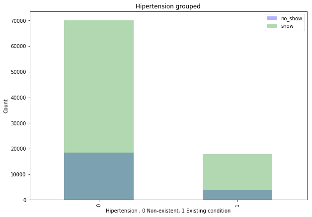

```python
#investigate correlation between medical condition and noshow - Hypertension
fig, ax = plt.subplots(figsize=(10,7))
df_ns.Hipertension[no_show].value_counts().plot(kind='bar',alpha=0.3,color='blue' ,label='no_show')
df_ns.Hipertension[show].value_counts().plot(kind='bar', alpha=0.3, color='green',label='show')
plt.legend()
plt.xlabel('Hipertension , 0 Non-existent, 1 Existing condition')
plt.ylabel('Count')
plt.title('Hipertension grouped');
```

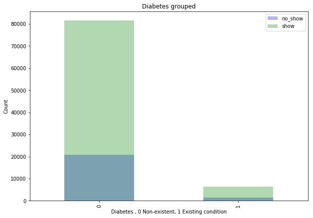

```python
#investigate correlation between medical condition and noshow - Diabetes
fig, ax = plt.subplots(figsize=(10,7))
df_ns.Diabetes[no_show].value_counts().plot(kind='bar',alpha=0.3,color='blue' ,label='no_show')
df_ns.Diabetes[show].value_counts().plot(kind='bar', alpha=0.3, color='green',label='show')
plt.legend()
plt.xlabel('Diabetes , 0 Non-existent, 1 Existing condition')
plt.ylabel('Count')
plt.title('Diabetes grouped');
```

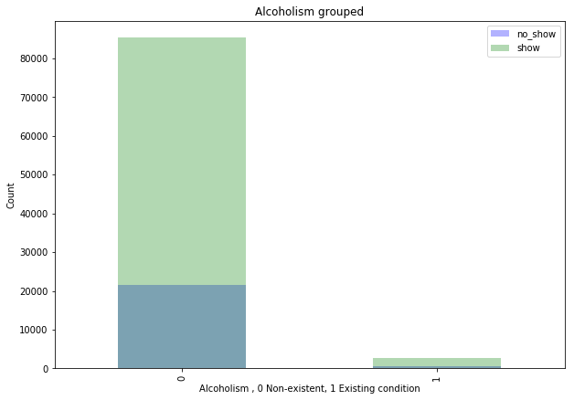

```python
#investigate correlation between medical condition and noshow - Alcoholism
fig, ax = plt.subplots(figsize=(10,7))
df_ns.Alcoholism[no_show].value_counts().plot(kind='bar',alpha=0.3,color='blue' ,label='no_show')
df_ns.Alcoholism[show].value_counts().plot(kind='bar', alpha=0.3, color='green',label='show')
plt.legend()
plt.xlabel('Alcoholism , 0 Non-existent, 1 Existing condition')
plt.ylabel('Count')
plt.title('Alcoholism grouped');
```

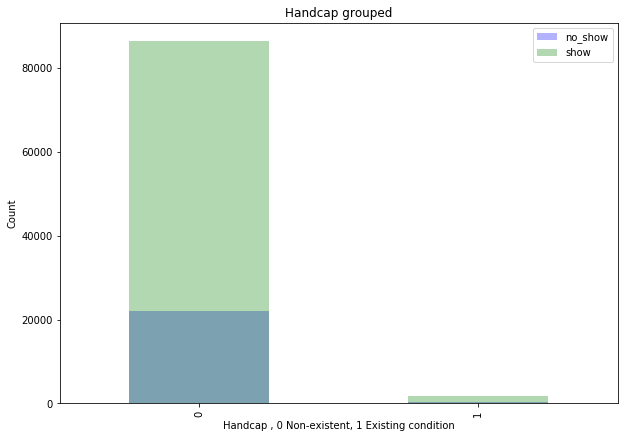

```python
#investigate correlation between medical condition and noshow - Handcap
fig, ax = plt.subplots(figsize=(10,7))
df_ns.Handcap[no_show].value_counts().plot(kind='bar',alpha=0.3,color='blue' ,label='no_show')
df_ns.Handcap[show].value_counts().plot(kind='bar', alpha=0.3, color='green',label='show')
plt.legend()
plt.xlabel('Handcap , 0 Non-existent, 1 Existing condition')
plt.ylabel('Count')
plt.title('Handcap grouped');
```

An additional question is added related to SMS messaging to investigate what effect they have on patient showing up to their appointment.

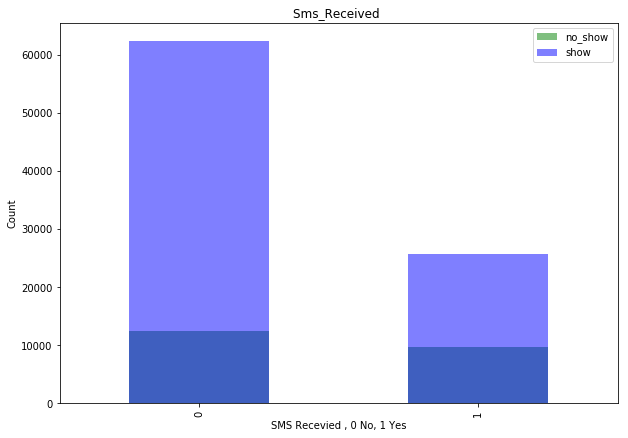

```python
# let us investigarte number of messages sent and thir effect on show and noshow
fig, ax = plt.subplots(figsize=(10,7))
df_ns.SMS_received[no_show].value_counts().plot(kind='bar',alpha=0.5,color='green' ,label='no_show')
df_ns.SMS_received[show].value_counts().plot(kind='bar', alpha=0.5, color='blue',label='show')
plt.legend()
plt.xlabel('SMS Recevied , 0 No, 1 Yes')
plt.ylabel('Count')
plt.title('Sms_Received ');
```

## Conclusions

### Limitations: There are couple of Limitations in our data

1- Neighbourhood Location require deeper analysis and dataset to establish the geographical characteristics of those Neighbourhood where noshow is highest

2- Sms_received does not specify when the sms what sent and therefore cannt draw any relation between day of Sms_received and AppointmentDay